# Risk Factor Analysis

## Outcome Variable

**Outcome Variable:** ever_wasted

## Predictor Variables

**Intervention Variable:** single

**Adjustment Set:**

- arm
- W_mage
- meducyrs
- feducyrs
- W_mhtcm
- W_mwtkg
- W_mbmi
- delta_W_mage
- delta_meducyrs
- delta_feducyrs
- delta_W_mhtcm
- delta_W_mwtkg
- delta_W_mbmi

## Stratifying Variables

The analysis was stratified on these variable(s):

- agecat
- studyid
- country

## Data Summary

| agecat | studyid | country | single | ever_wasted | n_cell | n |
| --- | --- | --- | --- | --- | --- | --- |
| 0-24 months | ki0047075b-MAL-ED | BANGLADESH | 0 | 0 | 176 | 263 |
| 0-24 months | ki0047075b-MAL-ED | BANGLADESH | 0 | 1 | 87 | 263 |
| 0-24 months | ki0047075b-MAL-ED | BANGLADESH | 1 | 0 | 0 | 263 |
| 0-24 months | ki0047075b-MAL-ED | BANGLADESH | 1 | 1 | 0 | 263 |
| 0-24 months | ki0047075b-MAL-ED | BRAZIL | 0 | 0 | 182 | 233 |
| 0-24 months | ki0047075b-MAL-ED | BRAZIL | 0 | 1 | 15 | 233 |
| 0-24 months | ki0047075b-MAL-ED | BRAZIL | 1 | 0 | 32 | 233 |
| 0-24 months | ki0047075b-MAL-ED | BRAZIL | 1 | 1 | 4 | 233 |
| 0-24 months | ki0047075b-MAL-ED | INDIA | 0 | 0 | 132 | 249 |
| 0-24 months | ki0047075b-MAL-ED | INDIA | 0 | 1 | 117 | 249 |
| 0-24 months | ki0047075b-MAL-ED | INDIA | 1 | 0 | 0 | 249 |
| 0-24 months | ki0047075b-MAL-ED | INDIA | 1 | 1 | 0 | 249 |
| 0-24 months | ki0047075b-MAL-ED | NEPAL | 0 | 0 | 171 | 240 |
| 0-24 months | ki0047075b-MAL-ED | NEPAL | 0 | 1 | 69 | 240 |
| 0-24 months | ki0047075b-MAL-ED | NEPAL | 1 | 0 | 0 | 240 |
| 0-24 months | ki0047075b-MAL-ED | NEPAL | 1 | 1 | 0 | 240 |
| 0-24 months | ki0047075b-MAL-ED | PERU | 0 | 0 | 248 | 302 |
| 0-24 months | ki0047075b-MAL-ED | PERU | 0 | 1 | 20 | 302 |
| 0-24 months | ki0047075b-MAL-ED | PERU | 1 | 0 | 28 | 302 |
| 0-24 months | ki0047075b-MAL-ED | PERU | 1 | 1 | 6 | 302 |
| 0-24 months | ki0047075b-MAL-ED | SOUTH AFRICA | 0 | 0 | 143 | 312 |
| 0-24 months | ki0047075b-MAL-ED | SOUTH AFRICA | 0 | 1 | 33 | 312 |
| 0-24 months | ki0047075b-MAL-ED | SOUTH AFRICA | 1 | 0 | 108 | 312 |
| 0-24 months | ki0047075b-MAL-ED | SOUTH AFRICA | 1 | 1 | 28 | 312 |
| 0-24 months | ki0047075b-MAL-ED | TANZANIA, UNITED REPUBLIC OF | 0 | 0 | 222 | 261 |
| 0-24 months | ki0047075b-MAL-ED | TANZANIA, UNITED REPUBLIC OF | 0 | 1 | 29 | 261 |
| 0-24 months | ki0047075b-MAL-ED | TANZANIA, UNITED REPUBLIC OF | 1 | 0 | 7 | 261 |
| 0-24 months | ki0047075b-MAL-ED | TANZANIA, UNITED REPUBLIC OF | 1 | 1 | 3 | 261 |
| 0-24 months | ki1066203-TanzaniaChild2 | TANZANIA, UNITED REPUBLIC OF | 0 | 0 | 1643 | 2375 |
| 0-24 months | ki1066203-TanzaniaChild2 | TANZANIA, UNITED REPUBLIC OF | 0 | 1 | 508 | 2375 |

[output cut: 138 more lines]

The following strata were considered:

- agecat: 0-24 months, studyid: ki0047075b-MAL-ED, country: BANGLADESH
- agecat: 0-24 months, studyid: ki0047075b-MAL-ED, country: BRAZIL
- agecat: 0-24 months, studyid: ki0047075b-MAL-ED, country: INDIA
- agecat: 0-24 months, studyid: ki0047075b-MAL-ED, country: NEPAL
- agecat: 0-24 months, studyid: ki0047075b-MAL-ED, country: PERU
- agecat: 0-24 months, studyid: ki0047075b-MAL-ED, country: SOUTH AFRICA
- agecat: 0-24 months, studyid: ki0047075b-MAL-ED, country: TANZANIA, UNITED REPUBLIC OF
- agecat: 0-24 months, studyid: ki1066203-TanzaniaChild2, country: TANZANIA, UNITED REPUBLIC OF
- agecat: 0-24 months, studyid: ki1112895-Guatemala BSC, country: GUATEMALA
- agecat: 0-24 months, studyid: ki1119695-PROBIT, country: BELARUS
- agecat: 0-24 months, studyid: ki1126311-ZVITAMBO, country: ZIMBABWE
- agecat: 0-24 months, studyid: ki1135781-COHORTS, country: GUATEMALA
- agecat: 0-24 months, studyid: ki1135781-COHORTS, country: INDIA
- agecat: 0-24 months, studyid: ki1135781-COHORTS, country: PHILIPPINES
- agecat: 0-6 months, studyid: ki0047075b-MAL-ED, country: BANGLADESH
- agecat: 0-6 months, studyid: ki0047075b-MAL-ED, country: BRAZIL
- agecat: 0-6 months, studyid: ki0047075b-MAL-ED, country: INDIA
- agecat: 0-6 months, studyid: ki0047075b-MAL-ED, country: NEPAL
- agecat: 0-6 months, studyid: ki0047075b-MAL-ED, country: PERU
- agecat: 0-6 months, studyid: ki0047075b-MAL-ED, country: SOUTH AFRICA
- agecat: 0-6 months, studyid: ki0047075b-MAL-ED, country: TANZANIA, UNITED REPUBLIC OF
- agecat: 0-6 months, studyid: ki1066203-TanzaniaChild2, country: TANZANIA, UNITED REPUBLIC OF
- agecat: 0-6 months, studyid: ki1112895-Guatemala BSC, country: GUATEMALA
- agecat: 0-6 months, studyid: ki1119695-PROBIT, country: BELARUS
- agecat: 0-6 months, studyid: ki1126311-ZVITAMBO, country: ZIMBABWE
- agecat: 0-6 months, studyid: ki1135781-COHORTS, country: GUATEMALA
- agecat: 0-6 months, studyid: ki1135781-COHORTS, country: INDIA
- agecat: 0-6 months, studyid: ki1135781-COHORTS, country: PHILIPPINES
- agecat: 6-24 months, studyid: ki0047075b-MAL-ED, country: BANGLADESH
- agecat: 6-24 months, studyid: ki0047075b-MAL-ED, country: BRAZIL
- agecat: 6-24 months, studyid: ki0047075b-MAL-ED, country: INDIA
- agecat: 6-24 months, studyid: ki0047075b-MAL-ED, country: NEPAL
- agecat: 6-24 months, studyid: ki0047075b-MAL-ED, country: PERU
- agecat: 6-24 months, studyid: ki0047075b-MAL-ED, country: SOUTH AFRICA
- agecat: 6-24 months, studyid: ki0047075b-MAL-ED, country: TANZANIA, UNITED REPUBLIC OF
- agecat: 6-24 months, studyid: ki1066203-TanzaniaChild2, country: TANZANIA, UNITED REPUBLIC OF
- agecat: 6-24 months, studyid: ki1112895-Guatemala BSC, country: GUATEMALA
- agecat: 6-24 months, studyid: ki1119695-PROBIT, country: BELARUS
- agecat: 6-24 months, studyid: ki1126311-ZVITAMBO, country: ZIMBABWE
- agecat: 6-24 months, studyid: ki1135781-COHORTS, country: GUATEMALA
- agecat: 6-24 months, studyid: ki1135781-COHORTS, country: INDIA
- agecat: 6-24 months, studyid: ki1135781-COHORTS, country: PHILIPPINES

### Dropped Strata

Some strata were dropped due to rare outcomes:

- agecat: 0-24 months, studyid: ki0047075b-MAL-ED, country: BANGLADESH
- agecat: 0-24 months, studyid: ki0047075b-MAL-ED, country: BRAZIL
- agecat: 0-24 months, studyid: ki0047075b-MAL-ED, country: INDIA
- agecat: 0-24 months, studyid: ki0047075b-MAL-ED, country: NEPAL
- agecat: 0-24 months, studyid: ki0047075b-MAL-ED, country: TANZANIA, UNITED REPUBLIC OF
- agecat: 0-24 months, studyid: ki1112895-Guatemala BSC, country: GUATEMALA
- agecat: 0-24 months, studyid: ki1135781-COHORTS, country: INDIA
- agecat: 0-6 months, studyid: ki0047075b-MAL-ED, country: BANGLADESH
- agecat: 0-6 months, studyid: ki0047075b-MAL-ED, country: BRAZIL
- agecat: 0-6 months, studyid: ki0047075b-MAL-ED, country: INDIA
- agecat: 0-6 months, studyid: ki0047075b-MAL-ED, country: NEPAL
- agecat: 0-6 months, studyid: ki0047075b-MAL-ED, country: PERU
- agecat: 0-6 months, studyid: ki0047075b-MAL-ED, country: TANZANIA, UNITED REPUBLIC OF
- agecat: 0-6 months, studyid: ki1112895-Guatemala BSC, country: GUATEMALA
- agecat: 0-6 months, studyid: ki1135781-COHORTS, country: INDIA
- agecat: 6-24 months, studyid: ki0047075b-MAL-ED, country: BANGLADESH
- agecat: 6-24 months, studyid: ki0047075b-MAL-ED, country: BRAZIL
- agecat: 6-24 months, studyid: ki0047075b-MAL-ED, country: INDIA
- agecat: 6-24 months, studyid: ki0047075b-MAL-ED, country: NEPAL
- agecat: 6-24 months, studyid: ki0047075b-MAL-ED, country: PERU
- agecat: 6-24 months, studyid: ki0047075b-MAL-ED, country: TANZANIA, UNITED REPUBLIC OF
- agecat: 6-24 months, studyid: ki1112895-Guatemala BSC, country: GUATEMALA
- agecat: 6-24 months, studyid: ki1119695-PROBIT, country: BELARUS
- agecat: 6-24 months, studyid: ki1135781-COHORTS, country: INDIA

## Methods Detail

We’re interested in the causal parameters $E[Y_a]$ for all values of $a \in \mathcal{A}$. These parameters represent the mean outcome if, possibly contrary to fact, we intervened to set all units to have $A=a$. Under the randomization and positivity assumptions, these are identified by the statistical parameters $\psi_a=E_W[E_{Y|A,W}(Y|A=a,W)]$. In addition, we’re interested in the mean of $Y$, $E[Y]$ under no intervention (the observed mean). We will estimate these parameters by using SuperLearner to fit the relevant likelihood factors – $E_{Y|A,W}(Y|A=a,W)$ and $p(A=a|W)$, and then updating our likelihood fit using a joint TMLE.

For unadjusted analyses ($W=\{\}$), initial likelihoods were estimated using Lrnr_glm to estimate the simple $E(Y|A)$ and Lrnr_mean to estimate $p(A)$. For adjusted analyses, a small library containing Lrnr_glmnet, Lrnr_xgboost, and Lrnr_mean was used.

Having estimated these parameters, we will then use the delta method to estimate relative risks and attributable risks relative to a prespecified baseline level of $A$.

# Results Detail

## Results Plots

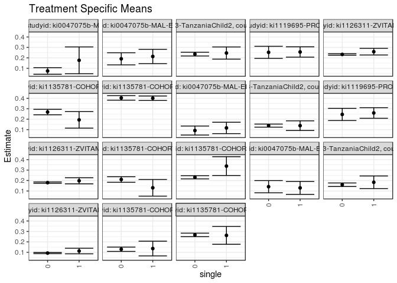

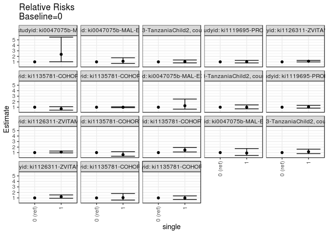

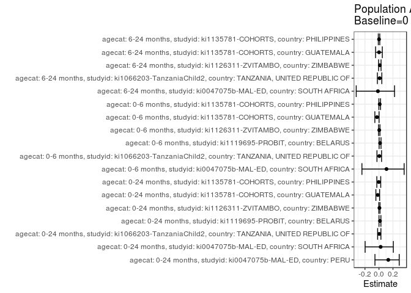

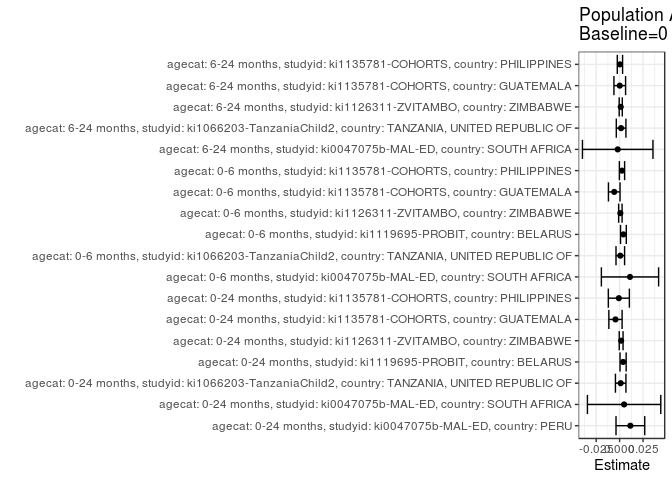

## Results Table

### Parameter: TSM

| agecat | studyid | country | intervention_level | baseline_level | estimate | ci_lower | ci_upper |
| --- | --- | --- | --- | --- | --- | --- | --- |
| 0-24 months | ki0047075b-MAL-ED | PERU | 0 | NA | 0.0746269 | 0.0431126 | 0.1061411 |
| 0-24 months | ki0047075b-MAL-ED | PERU | 1 | NA | 0.1764706 | 0.0481180 | 0.3048232 |
| 0-24 months | ki0047075b-MAL-ED | SOUTH AFRICA | 0 | NA | 0.1907364 | 0.1328983 | 0.2485746 |
| 0-24 months | ki0047075b-MAL-ED | SOUTH AFRICA | 1 | NA | 0.2132760 | 0.1447974 | 0.2817546 |
| 0-24 months | ki1066203-TanzaniaChild2 | TANZANIA, UNITED REPUBLIC OF | 0 | NA | 0.2359133 | 0.2179660 | 0.2538605 |
| 0-24 months | ki1066203-TanzaniaChild2 | TANZANIA, UNITED REPUBLIC OF | 1 | NA | 0.2460891 | 0.1877912 | 0.3043869 |
| 0-24 months | ki1119695-PROBIT | BELARUS | 0 | NA | 0.2528968 | 0.1949925 | 0.3108012 |
| 0-24 months | ki1119695-PROBIT | BELARUS | 1 | NA | 0.2562842 | 0.2068603 | 0.3057080 |
| 0-24 months | ki1126311-ZVITAMBO | ZIMBABWE | 0 | NA | 0.2328296 | 0.2255222 | 0.2401371 |
| 0-24 months | ki1126311-ZVITAMBO | ZIMBABWE | 1 | NA | 0.2590339 | 0.2272927 | 0.2907751 |
| 0-24 months | ki1135781-COHORTS | GUATEMALA | 0 | NA | 0.2684072 | 0.2421932 | 0.2946211 |
| 0-24 months | ki1135781-COHORTS | GUATEMALA | 1 | NA | 0.1934726 | 0.1144400 | 0.2725052 |
| 0-24 months | ki1135781-COHORTS | PHILIPPINES | 0 | NA | 0.4034750 | 0.3819884 | 0.4249615 |
| 0-24 months | ki1135781-COHORTS | PHILIPPINES | 1 | NA | 0.4007372 | 0.3793703 | 0.4221042 |
| 0-6 months | ki0047075b-MAL-ED | SOUTH AFRICA | 0 | NA | 0.0914989 | 0.0484822 | 0.1345156 |
| 0-6 months | ki0047075b-MAL-ED | SOUTH AFRICA | 1 | NA | 0.1164226 | 0.0619627 | 0.1708825 |
| 0-6 months | ki1066203-TanzaniaChild2 | TANZANIA, UNITED REPUBLIC OF | 0 | NA | 0.1386525 | 0.1240368 | 0.1532683 |
| 0-6 months | ki1066203-TanzaniaChild2 | TANZANIA, UNITED REPUBLIC OF | 1 | NA | 0.1380434 | 0.0919029 | 0.1841838 |
| 0-6 months | ki1119695-PROBIT | BELARUS | 0 | NA | 0.2457357 | 0.1871490 | 0.3043224 |
| 0-6 months | ki1119695-PROBIT | BELARUS | 1 | NA | 0.2597178 | 0.2091433 | 0.3102924 |
| 0-6 months | ki1126311-ZVITAMBO | ZIMBABWE | 0 | NA | 0.1798342 | 0.1731766 | 0.1864918 |
| 0-6 months | ki1126311-ZVITAMBO | ZIMBABWE | 1 | NA | 0.1976416 | 0.1684709 | 0.2268123 |
| 0-6 months | ki1135781-COHORTS | GUATEMALA | 0 | NA | 0.2101124 | 0.1833337 | 0.2368910 |
| 0-6 months | ki1135781-COHORTS | GUATEMALA | 1 | NA | 0.1304348 | 0.0509292 | 0.2099404 |
| 0-6 months | ki1135781-COHORTS | PHILIPPINES | 0 | NA | 0.2311492 | 0.2157600 | 0.2465384 |
| 0-6 months | ki1135781-COHORTS | PHILIPPINES | 1 | NA | 0.3381378 | 0.2482380 | 0.4280377 |
| 6-24 months | ki0047075b-MAL-ED | SOUTH AFRICA | 0 | NA | 0.1410352 | 0.0830077 | 0.1990628 |
| 6-24 months | ki0047075b-MAL-ED | SOUTH AFRICA | 1 | NA | 0.1296408 | 0.0675982 | 0.1916835 |
| 6-24 months | ki1066203-TanzaniaChild2 | TANZANIA, UNITED REPUBLIC OF | 0 | NA | 0.1596668 | 0.1428523 | 0.1764812 |
| 6-24 months | ki1066203-TanzaniaChild2 | TANZANIA, UNITED REPUBLIC OF | 1 | NA | 0.1834252 | 0.1231316 | 0.2437189 |
| 6-24 months | ki1126311-ZVITAMBO | ZIMBABWE | 0 | NA | 0.0928914 | 0.0871766 | 0.0986061 |
| 6-24 months | ki1126311-ZVITAMBO | ZIMBABWE | 1 | NA | 0.1124688 | 0.0856785 | 0.1392592 |
| 6-24 months | ki1135781-COHORTS | GUATEMALA | 0 | NA | 0.1294701 | 0.1087531 | 0.1501871 |
| 6-24 months | ki1135781-COHORTS | GUATEMALA | 1 | NA | 0.1362194 | 0.0657977 | 0.2066411 |
| 6-24 months | ki1135781-COHORTS | PHILIPPINES | 0 | NA | 0.2666847 | 0.2498870 | 0.2834824 |
| 6-24 months | ki1135781-COHORTS | PHILIPPINES | 1 | NA | 0.2622385 | 0.1769282 | 0.3475488 |

### Parameter: E(Y)

| agecat | studyid | country | intervention_level | baseline_level | estimate | ci_lower | ci_upper |
| --- | --- | --- | --- | --- | --- | --- | --- |
| 0-24 months | ki0047075b-MAL-ED | PERU | NA | NA | 0.0860927 | 0.0544044 | 0.1177810 |
| 0-24 months | ki0047075b-MAL-ED | SOUTH AFRICA | NA | NA | 0.1955128 | 0.1514355 | 0.2395901 |
| 0-24 months | ki1066203-TanzaniaChild2 | TANZANIA, UNITED REPUBLIC OF | NA | NA | 0.2370526 | 0.2199455 | 0.2541598 |
| 0-24 months | ki1119695-PROBIT | BELARUS | NA | NA | 0.2565984 | 0.1993515 | 0.3138454 |
| 0-24 months | ki1126311-ZVITAMBO | ZIMBABWE | NA | NA | 0.2344594 | 0.2274118 | 0.2415070 |
| 0-24 months | ki1135781-COHORTS | GUATEMALA | NA | NA | 0.2639933 | 0.2390117 | 0.2889749 |
| 0-24 months | ki1135781-COHORTS | PHILIPPINES | NA | NA | 0.4026622 | 0.3851243 | 0.4202002 |
| 0-6 months | ki0047075b-MAL-ED | SOUTH AFRICA | NA | NA | 0.1025641 | 0.0688457 | 0.1362825 |
| 0-6 months | ki1066203-TanzaniaChild2 | TANZANIA, UNITED REPUBLIC OF | NA | NA | 0.1393684 | 0.1254369 | 0.1532999 |
| 0-6 months | ki1119695-PROBIT | BELARUS | NA | NA | 0.2497780 | 0.1917926 | 0.3077635 |
| 0-6 months | ki1126311-ZVITAMBO | ZIMBABWE | NA | NA | 0.1806250 | 0.1742041 | 0.1870460 |
| 0-6 months | ki1135781-COHORTS | GUATEMALA | NA | NA | 0.2043796 | 0.1788445 | 0.2299146 |
| 0-6 months | ki1135781-COHORTS | PHILIPPINES | NA | NA | 0.2336884 | 0.2185531 | 0.2488237 |
| 6-24 months | ki0047075b-MAL-ED | SOUTH AFRICA | NA | NA | 0.1389961 | 0.0967835 | 0.1812087 |
| 6-24 months | ki1066203-TanzaniaChild2 | TANZANIA, UNITED REPUBLIC OF | NA | NA | 0.1612581 | 0.1451483 | 0.1773679 |
| 6-24 months | ki1126311-ZVITAMBO | ZIMBABWE | NA | NA | 0.0940845 | 0.0885396 | 0.0996294 |
| 6-24 months | ki1135781-COHORTS | GUATEMALA | NA | NA | 0.1296130 | 0.1098539 | 0.1493721 |
| 6-24 months | ki1135781-COHORTS | PHILIPPINES | NA | NA | 0.2670270 | 0.2505637 | 0.2834903 |

### Parameter: RR

| agecat | studyid | country | intervention_level | baseline_level | estimate | ci_lower | ci_upper |
| --- | --- | --- | --- | --- | --- | --- | --- |
| 0-24 months | ki0047075b-MAL-ED | PERU | 0 | 0 | 1.0000000 | 1.0000000 | 1.000000 |
| 0-24 months | ki0047075b-MAL-ED | PERU | 1 | 0 | 2.3647059 | 1.0198121 | 5.483200 |
| 0-24 months | ki0047075b-MAL-ED | SOUTH AFRICA | 0 | 0 | 1.0000000 | 1.0000000 | 1.000000 |
| 0-24 months | ki0047075b-MAL-ED | SOUTH AFRICA | 1 | 0 | 1.1181712 | 0.7178801 | 1.741665 |
| 0-24 months | ki1066203-TanzaniaChild2 | TANZANIA, UNITED REPUBLIC OF | 0 | 0 | 1.0000000 | 1.0000000 | 1.000000 |
| 0-24 months | ki1066203-TanzaniaChild2 | TANZANIA, UNITED REPUBLIC OF | 1 | 0 | 1.0431336 | 0.8134892 | 1.337606 |
| 0-24 months | ki1119695-PROBIT | BELARUS | 0 | 0 | 1.0000000 | 1.0000000 | 1.000000 |
| 0-24 months | ki1119695-PROBIT | BELARUS | 1 | 0 | 1.0133942 | 0.8035455 | 1.278045 |
| 0-24 months | ki1126311-ZVITAMBO | ZIMBABWE | 0 | 0 | 1.0000000 | 1.0000000 | 1.000000 |
| 0-24 months | ki1126311-ZVITAMBO | ZIMBABWE | 1 | 0 | 1.1125470 | 0.9804283 | 1.262469 |
| 0-24 months | ki1135781-COHORTS | GUATEMALA | 0 | 0 | 1.0000000 | 1.0000000 | 1.000000 |
| 0-24 months | ki1135781-COHORTS | GUATEMALA | 1 | 0 | 0.7208175 | 0.4736568 | 1.096950 |
| 0-24 months | ki1135781-COHORTS | PHILIPPINES | 0 | 0 | 1.0000000 | 1.0000000 | 1.000000 |
| 0-24 months | ki1135781-COHORTS | PHILIPPINES | 1 | 0 | 0.9932147 | 0.9211857 | 1.070876 |
| 0-6 months | ki0047075b-MAL-ED | SOUTH AFRICA | 0 | 0 | 1.0000000 | 1.0000000 | 1.000000 |
| 0-6 months | ki0047075b-MAL-ED | SOUTH AFRICA | 1 | 0 | 1.2723934 | 0.6538107 | 2.476229 |
| 0-6 months | ki1066203-TanzaniaChild2 | TANZANIA, UNITED REPUBLIC OF | 0 | 0 | 1.0000000 | 1.0000000 | 1.000000 |
| 0-6 months | ki1066203-TanzaniaChild2 | TANZANIA, UNITED REPUBLIC OF | 1 | 0 | 0.9956065 | 0.7012880 | 1.413445 |
| 0-6 months | ki1119695-PROBIT | BELARUS | 0 | 0 | 1.0000000 | 1.0000000 | 1.000000 |
| 0-6 months | ki1119695-PROBIT | BELARUS | 1 | 0 | 1.0568990 | 0.8348969 | 1.337932 |
| 0-6 months | ki1126311-ZVITAMBO | ZIMBABWE | 0 | 0 | 1.0000000 | 1.0000000 | 1.000000 |
| 0-6 months | ki1126311-ZVITAMBO | ZIMBABWE | 1 | 0 | 1.0990211 | 0.9439262 | 1.279600 |
| 0-6 months | ki1135781-COHORTS | GUATEMALA | 0 | 0 | 1.0000000 | 1.0000000 | 1.000000 |
| 0-6 months | ki1135781-COHORTS | GUATEMALA | 1 | 0 | 0.6207859 | 0.3330396 | 1.157145 |
| 0-6 months | ki1135781-COHORTS | PHILIPPINES | 0 | 0 | 1.0000000 | 1.0000000 | 1.000000 |
| 0-6 months | ki1135781-COHORTS | PHILIPPINES | 1 | 0 | 1.4628552 | 1.1121539 | 1.924145 |
| 6-24 months | ki0047075b-MAL-ED | SOUTH AFRICA | 0 | 0 | 1.0000000 | 1.0000000 | 1.000000 |
| 6-24 months | ki0047075b-MAL-ED | SOUTH AFRICA | 1 | 0 | 0.9192087 | 0.4896767 | 1.725515 |
| 6-24 months | ki1066203-TanzaniaChild2 | TANZANIA, UNITED REPUBLIC OF | 0 | 0 | 1.0000000 | 1.0000000 | 1.000000 |
| 6-24 months | ki1066203-TanzaniaChild2 | TANZANIA, UNITED REPUBLIC OF | 1 | 0 | 1.1488003 | 0.8137481 | 1.621807 |
| 6-24 months | ki1126311-ZVITAMBO | ZIMBABWE | 0 | 0 | 1.0000000 | 1.0000000 | 1.000000 |
| 6-24 months | ki1126311-ZVITAMBO | ZIMBABWE | 1 | 0 | 1.2107568 | 0.9468791 | 1.548172 |
| 6-24 months | ki1135781-COHORTS | GUATEMALA | 0 | 0 | 1.0000000 | 1.0000000 | 1.000000 |
| 6-24 months | ki1135781-COHORTS | GUATEMALA | 1 | 0 | 1.0521307 | 0.6124836 | 1.807361 |
| 6-24 months | ki1135781-COHORTS | PHILIPPINES | 0 | 0 | 1.0000000 | 1.0000000 | 1.000000 |
| 6-24 months | ki1135781-COHORTS | PHILIPPINES | 1 | 0 | 0.9833279 | 0.7060549 | 1.369488 |

### Parameter: PAR

| agecat | studyid | country | intervention_level | baseline_level | estimate | ci_lower | ci_upper |
| --- | --- | --- | --- | --- | --- | --- | --- |
| 0-24 months | ki0047075b-MAL-ED | PERU | 0 | NA | 0.0114658 | -0.0038516 | 0.0267833 |
| 0-24 months | ki0047075b-MAL-ED | SOUTH AFRICA | 0 | NA | 0.0047764 | -0.0343533 | 0.0439061 |
| 0-24 months | ki1066203-TanzaniaChild2 | TANZANIA, UNITED REPUBLIC OF | 0 | NA | 0.0011394 | -0.0044531 | 0.0067318 |
| 0-24 months | ki1119695-PROBIT | BELARUS | 0 | NA | 0.0037016 | 0.0004339 | 0.0069693 |
| 0-24 months | ki1126311-ZVITAMBO | ZIMBABWE | 0 | NA | 0.0016298 | -0.0004032 | 0.0036627 |
| 0-24 months | ki1135781-COHORTS | GUATEMALA | 0 | NA | -0.0044138 | -0.0114789 | 0.0026512 |
| 0-24 months | ki1135781-COHORTS | PHILIPPINES | 0 | NA | -0.0008127 | -0.0120306 | 0.0104051 |
| 0-6 months | ki0047075b-MAL-ED | SOUTH AFRICA | 0 | NA | 0.0110652 | -0.0194550 | 0.0415854 |
| 0-6 months | ki1066203-TanzaniaChild2 | TANZANIA, UNITED REPUBLIC OF | 0 | NA | 0.0007159 | -0.0038626 | 0.0052944 |
| 0-6 months | ki1119695-PROBIT | BELARUS | 0 | NA | 0.0040423 | 0.0009721 | 0.0071125 |
| 0-6 months | ki1126311-ZVITAMBO | ZIMBABWE | 0 | NA | 0.0007908 | -0.0010509 | 0.0026326 |
| 0-6 months | ki1135781-COHORTS | GUATEMALA | 0 | NA | -0.0057328 | -0.0119082 | 0.0004426 |
| 0-6 months | ki1135781-COHORTS | PHILIPPINES | 0 | NA | 0.0025392 | -0.0002516 | 0.0053300 |
| 6-24 months | ki0047075b-MAL-ED | SOUTH AFRICA | 0 | NA | -0.0020391 | -0.0396471 | 0.0355689 |
| 6-24 months | ki1066203-TanzaniaChild2 | TANZANIA, UNITED REPUBLIC OF | 0 | NA | 0.0015914 | -0.0035325 | 0.0067152 |
| 6-24 months | ki1126311-ZVITAMBO | ZIMBABWE | 0 | NA | 0.0011932 | -0.0004595 | 0.0028458 |
| 6-24 months | ki1135781-COHORTS | GUATEMALA | 0 | NA | 0.0001429 | -0.0060727 | 0.0063586 |
| 6-24 months | ki1135781-COHORTS | PHILIPPINES | 0 | NA | 0.0003423 | -0.0024782 | 0.0031628 |

### Parameter: PAF

| agecat | studyid | country | intervention_level | baseline_level | estimate | ci_lower | ci_upper |
| --- | --- | --- | --- | --- | --- | --- | --- |
| 0-24 months | ki0047075b-MAL-ED | PERU | 0 | NA | 0.1331803 | -0.0572850 | 0.2893340 |
| 0-24 months | ki0047075b-MAL-ED | SOUTH AFRICA | 0 | NA | 0.0244300 | -0.1975576 | 0.2052684 |
| 0-24 months | ki1066203-TanzaniaChild2 | TANZANIA, UNITED REPUBLIC OF | 0 | NA | 0.0048063 | -0.0190662 | 0.0281196 |
| 0-24 months | ki1119695-PROBIT | BELARUS | 0 | NA | 0.0144257 | 0.0006638 | 0.0279980 |
| 0-24 months | ki1126311-ZVITAMBO | ZIMBABWE | 0 | NA | 0.0069512 | -0.0017571 | 0.0155838 |
| 0-24 months | ki1135781-COHORTS | GUATEMALA | 0 | NA | -0.0167195 | -0.0438246 | 0.0096817 |
| 0-24 months | ki1135781-COHORTS | PHILIPPINES | 0 | NA | -0.0020184 | -0.0302621 | 0.0254510 |
| 0-6 months | ki0047075b-MAL-ED | SOUTH AFRICA | 0 | NA | 0.1078857 | -0.2430284 | 0.3597348 |
| 0-6 months | ki1066203-TanzaniaChild2 | TANZANIA, UNITED REPUBLIC OF | 0 | NA | 0.0051366 | -0.0282618 | 0.0374501 |
| 0-6 months | ki1119695-PROBIT | BELARUS | 0 | NA | 0.0161836 | 0.0026401 | 0.0295433 |
| 0-6 months | ki1126311-ZVITAMBO | ZIMBABWE | 0 | NA | 0.0043783 | -0.0058699 | 0.0145221 |
| 0-6 months | ki1135781-COHORTS | GUATEMALA | 0 | NA | -0.0280498 | -0.0586145 | 0.0016325 |
| 0-6 months | ki1135781-COHORTS | PHILIPPINES | 0 | NA | 0.0108657 | -0.0011697 | 0.0227565 |
| 6-24 months | ki0047075b-MAL-ED | SOUTH AFRICA | 0 | NA | -0.0146703 | -0.3244806 | 0.2226721 |
| 6-24 months | ki1066203-TanzaniaChild2 | TANZANIA, UNITED REPUBLIC OF | 0 | NA | 0.0098683 | -0.0224181 | 0.0411353 |
| 6-24 months | ki1126311-ZVITAMBO | ZIMBABWE | 0 | NA | 0.0126817 | -0.0050228 | 0.0300744 |
| 6-24 months | ki1135781-COHORTS | GUATEMALA | 0 | NA | 0.0011025 | -0.0480231 | 0.0479254 |
| 6-24 months | ki1135781-COHORTS | PHILIPPINES | 0 | NA | 0.0012820 | -0.0093397 | 0.0117920 |